# How Background Affects Happiness

Zeyu Yang, zy2327

People with different background often have different sense of happiness. For example, a child may think of eating candies or visiting zoo as happy. A young person may think of being admitted by a dream university as happy. A middle-age person may view promotion as happy. Age along with other factors such as gender, parenthood and so on could greatly change the way people think of happiness. Thus, this data story is going to find out how background(age, gender and parenthood) affect happiness.

# Age

Let’s first take a look at the distribution of age.

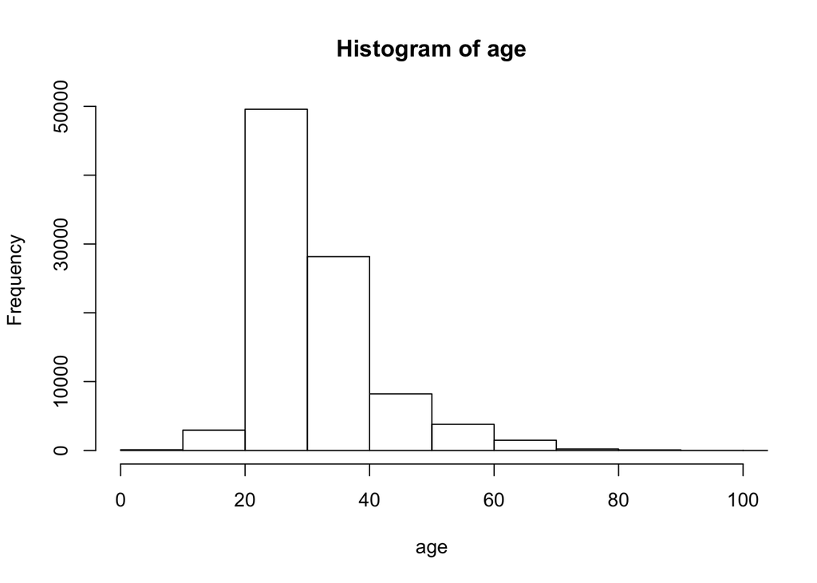

There are a great proportion of people aged 20-40. I am going to divide all the people into 5 groups: aged 10-20, 21-30, 31-40, 41-50 and 51-100. $*^1$

## Sentimental Analysis

**Sentimental Score:**

Sentiment score is a measurement of how positive or negative the words are. By computing the mean sentiment score of each sentence, we can see how positive/happy people are.

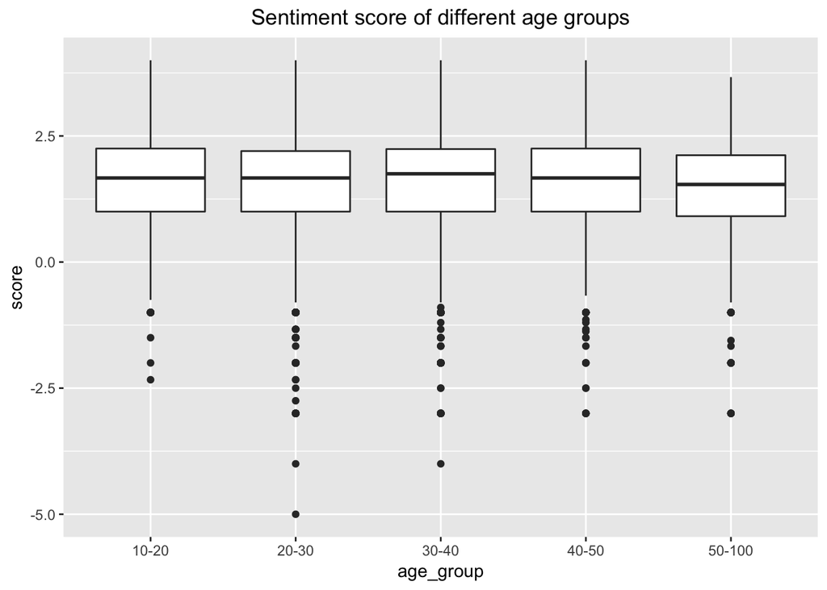

From the above plot, we can see that the range and median of the sentiment score of different age groups are almost the same. It show that they have similar happy level.

The negative dots shown in the plot is due to the limit of this method. The sentiment score can only show the emotional strength of individual words instead of the whole sentence: it can not understand negative sentence.

**Sentiment Category**

This part is grouping words into 10 segments: anger, anticipation, disgust, fear, joy, neagtive, positive, sadness, suprise and trust. Instead of measuring how strong the feeling of words are, it tries to find out what feelings different words express.

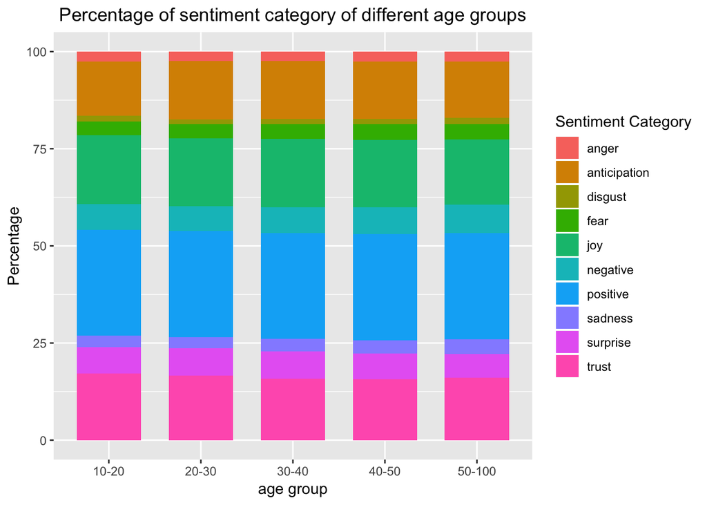

From the above plot, we can see the sentences mainly express feeling about positve, trust, joy and anticipation.

## Topics

In this part, we going to find out what relation/verb/objects that people mentioned most. $*^2$

**Relation**

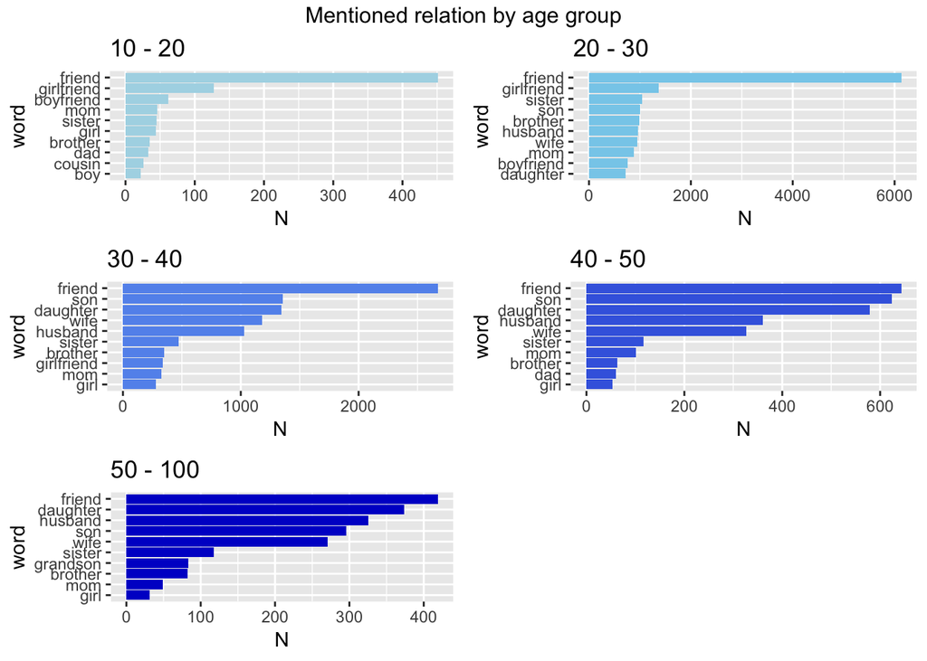

From the above plot, we can see that “friend” is the word that mentioned most among all age groups. It shows that friends are crucial to happiness.

**Verb**

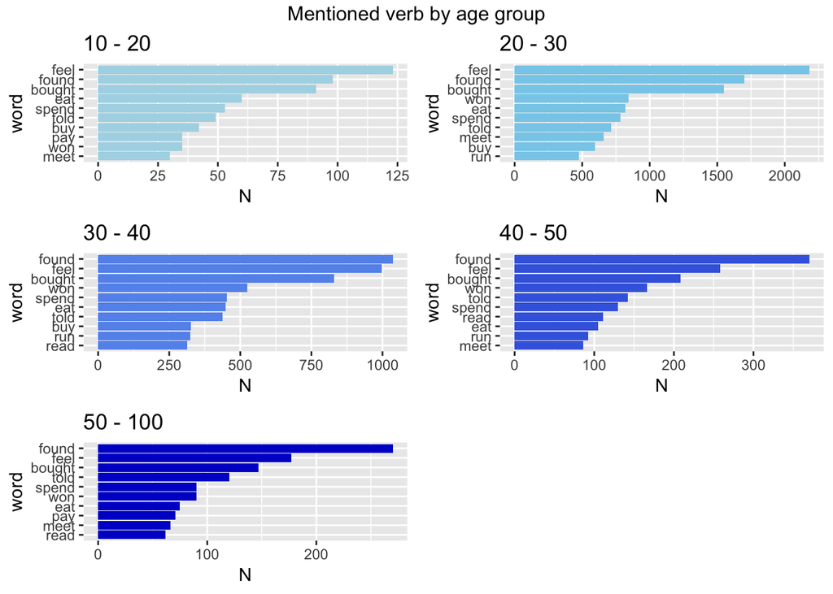

The top mentioned verbs among all age groups are “feel”, “found”, “bought”. “Eat” has also been mentioned a lot. I personally agree with this one as well since eating is quiting relieving.

**About Objects**

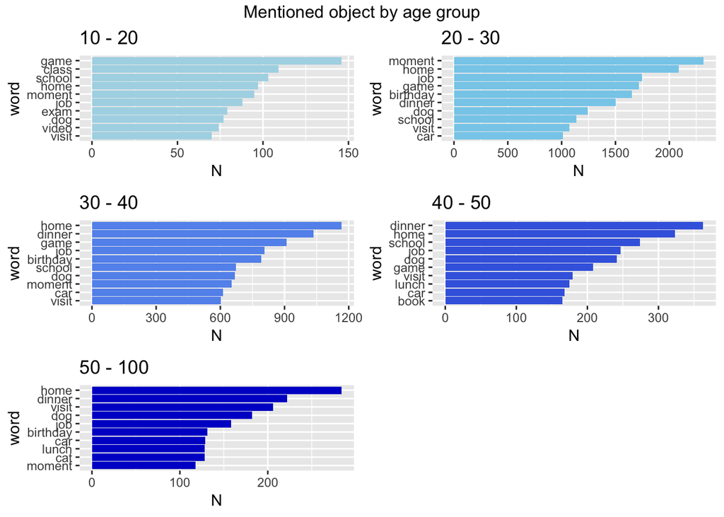

“School” shows up in first 4 age groups as well. But they might caused by different reasons. Younger one is more likely to be happy because of their own experience at school. Elder ones might be happy about their child at school.

# Gender, marital & Parenthood

Gender, marital & parenthood are factors other than age that might affects the sense of happiness. For example, being married or being parents is likely to make people happier.

## Gender & marital

This part will explore whether being married would brings people happiness.

```
##    gender marital mean score
## 1:      f married   1.520353
## 2:      f  single   1.520534
## 3:      m married   1.567624
## 4:      m  single   1.510581
```

From the above chart, it seems that males are happier when married while females maintain the same level of happiness. To validate this, here’s a t test:

```r
t.test(male.single,male.married)
```

```
##
##  Welch Two Sample t-test
##
## data:  male.single and male.married
## t = -1.6316, df = 3340.7, p-value = 0.1029
## alternative hypothesis: true difference in means is not equal to 0
## 95 percent confidence interval:
##  -0.12558951  0.01150445
## sample estimates:
## mean of x mean of y
##  1.510581  1.567624
```

```r
t.test(female.single,female.married)
```

```
##
##  Welch Two Sample t-test
##
## data:  female.single and female.married
## t = 0.005323, df = 4236.1, p-value = 0.9958
## alternative hypothesis: true difference in means is not equal to 0
## 95 percent confidence interval:
##  -0.06632119  0.06668230
## sample estimates:
## mean of x mean of y
##  1.520534  1.520353
```

## Gender & parenthood

```
##    gender parenthood mean score
## 1:      f          y   1.525225
## 2:      f          n   1.516134
## 3:      m          y   1.570979
## 4:      m          n   1.515167
```

```r
t.test(parent,nonparent)
```

[output not shown]

Next, let’s take a look at how happiness is affected by gender and parenthood.

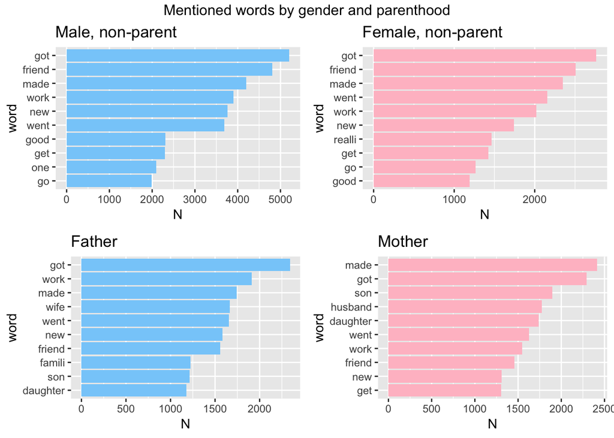

For females, son, husband and daughter are the top mentioned words by “mother”. They are mentioned more times than “work”.

**Explanation:**

$*^1$: Although there are some data as small as 3 and as large as 233. These data are considered invalid data and therefore not included in the groups.

$*^2$: Words of different topics are manually selected from the “bag_of_words” data.

Here are a few example of the list:

Person:

```
## [1] "friend"     "girlfriend" "family"     "people"     "boyfriend"
## [6] "sister"
```

Verb:

```
## [1] "played"   "feel"     "enjoyed"  "finished" "found"    "bought"
```

Object:

```
## [1] "dog"     "school"  "game"    "college" "class"   "moment"
```